# Propser Loan Data Analysis

## Introduction

The dataset contains peer-to-peer loan information for 113,937 loans with 81 variables on each loan from Prosper Funding LLC. I am going to explore the relationships among multiple variables using summary statistics and data visualizations.

The outline of this project is:

Introduction

Univariate Analysis

Bivariate Analysis

Multivariate Analysis

Summary

#### What is the structure of your dataset?

The dataset is about loan details and borrower information. The dataset has 113937 observations of 81 variables.Data types including string, int and float.

## Univariate Exploration

#### Describe 3 main feature(s) of interest in your dataset?

I consider Income range, Loan amount and BorrowerAPR as main variables for my analysis.I have analysed the relationship between these variables below.

### Income Range

```
Text(0.5,1,'Income Range Distribution')
```

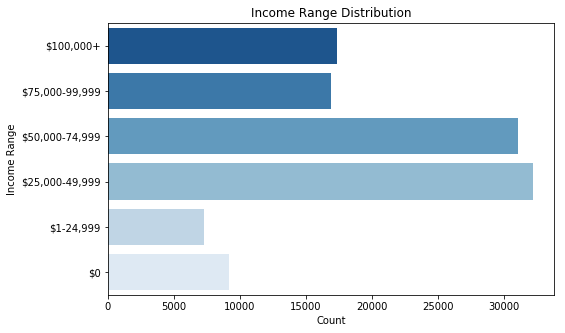

Looks like the number of borrowers for the 25k-49k range is almost same as the 50k-74k range. The amount of borrowers in the 75k-100k range again is almost similar to borrowers that have an income of over 100k.

### Loan Amount

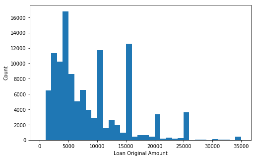

From the histogram,Most of the loans are requested below 10000 dollars, with 4000 being the most common amount.

### Borrower APR

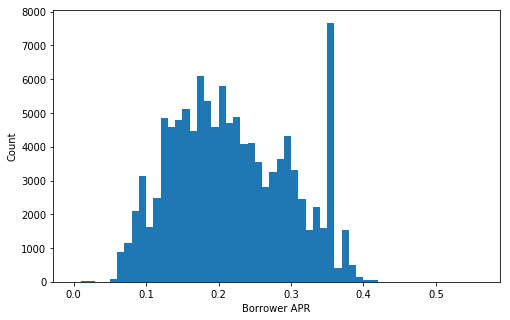

From the histogram, I can see a very shape peak between 0.35 and 0.36. Only very few loans have APR greater than 0.43.

### Monthly Installments

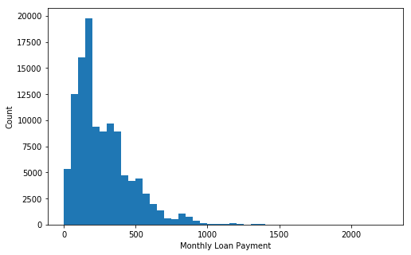

From the histogram, I found that most of the monthly loan payments are less than 1000 dollars, with most common payment amount per month between 170-210 $.

### Borrower Credit Rating

```
Text(0.5,1,'Borrower Ratings')
```

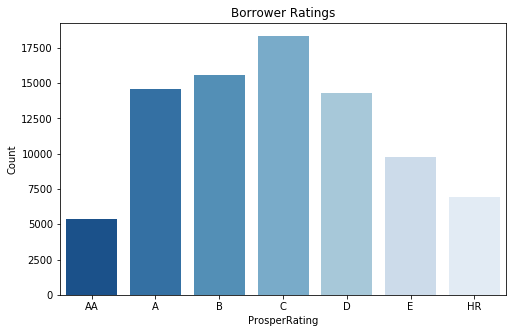

#### What are your supporting variables which help us understand the primary features in depth?

To understand more about the loan data, I have to include prosper rating and term variable.

## Bivariate Exploration

### Relationship between Loan Amount, Borrower APR and Monthly EMI variables

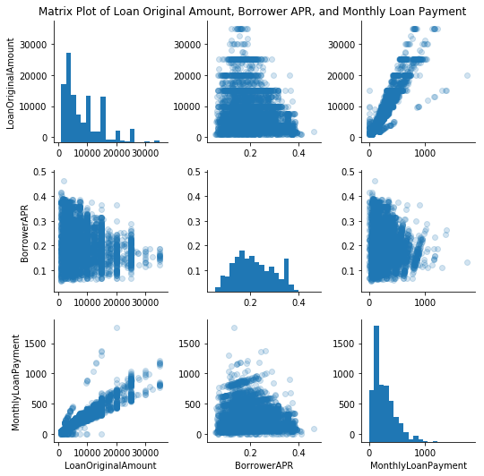

The scatter plot also shows that these loan original Amount and Borrower APR variables are negatively correlated, which is true,if the loan amount increases, the APR decreases. The loan original amount and the monthly loan payments , it makes sense since more the loan amount the monthly loan payment increase.

### Relationship between Loan Amount, Monthly EMI and Term variables

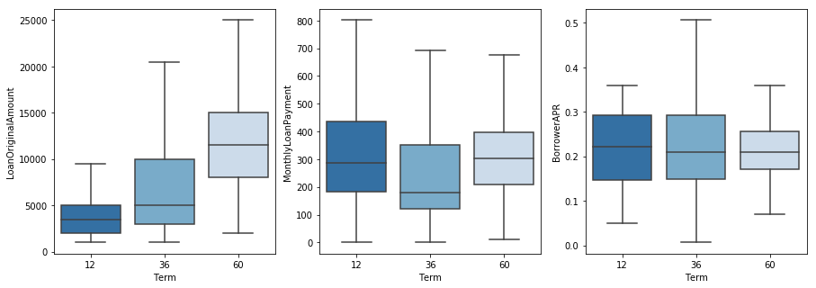

From the above boxplot, we can see a positive relation between loan amount and term, i.e. as the term increase the loan amount increase.Also, the mean borrowerAPR for the terms 36 and 60 is less 12 months term.

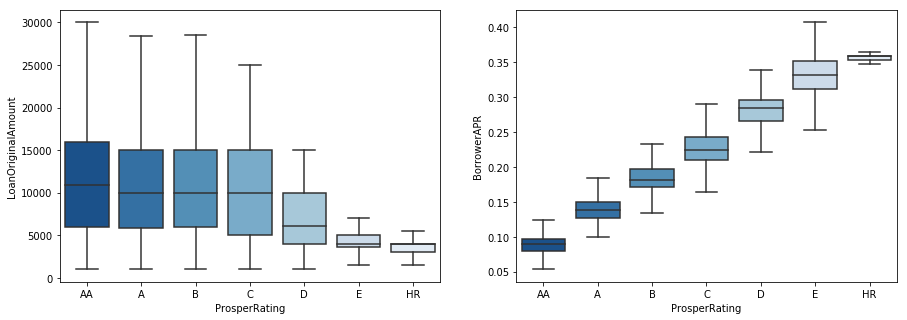

From the above boxplot, we can see a positive relation between loan amount and prosper rating, i.e. customers with better rating have can get loans for higher amounts. In the 2nd plot we see customers with better ratings have lower borrowerAPR i.e. borrower APR and prosper rating are negatively corellated.

### BorrowerAPR VS Loan Original Amount

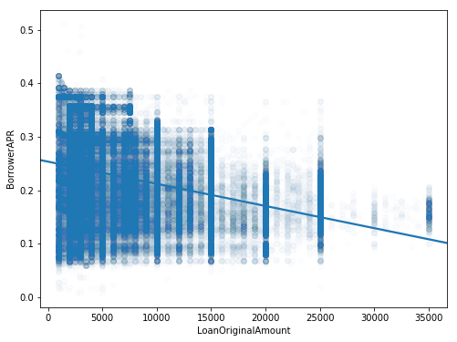

This plot shows that the range of APR decrease with the increase of loan amount. Overall, the borrower APR is negatively correlated with loan amount.

## Multivariate Exploration

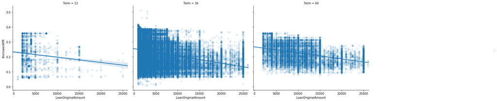

The relationship between borrowerAPR and loan original amount remain same with the increase of term. Term doesn't seem to have effect on relationship of APR and loan amount

### Explore BorrowerAPR, Prosper rating and Term

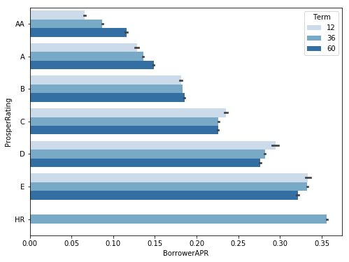

Interestingly,for customers with rating AA-B ratings, the APR increase with the increase of borrow term. However,for customers with rating C-HR, the borrower APR decrease with the increase of borrow term.

Lets, look at the rating and term effects on monthly payments and loan original amount variables

### Explore Loan amount, Monthly payments Prosper rating and Term

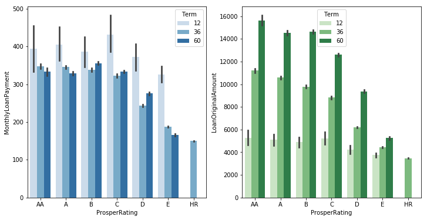

#### Were there any interesting or surprising interactions between features?

Interestingly,for customers with rating AA-B ratings, the APR increase with the increase of borrow term. However,for customers with rating C-HR, the borrower APR decrease with the increase of borrow term.

## Summary

In this project I selected a dataset from Prosper.com which includes 81 variables and 113,937 observations. I filtered the the variables I needed for my analysis and created a sub dataset.

I got some ideas of individual variable with use of bar charts and histograms. In the next step, I started to explore the relations among variables, especially those related to our target variable. I used the scatter matrix which shows multiple comparisons at once.

Finally to analyze and visulalize multiple variables I used barplot with color as my 3rd variable. The color here reperents the 3rd variable, a catagorical variable.